# Comprehensive Benchmarking Report: Quantum Inductive Biases in Toxicity Prediction

## 2. Why ToxCast? (The Failure of Tox21)

Initially, we tested our framework on Tox21 (12 tasks). However, Tox21 suffers from:

- **Severe Label Sparsity:** Heatmaps reveal over 30% missing labels.
- **Topological Bottlenecks:** Only ~8,000 molecules, severely limiting the ability to capture deep interactions.
- **Extreme Class Imbalance:** Inhibits the measurement of true algorithmic improvements due to noise.

**ToxCast**, containing 617 endpoints and dense multi-task interactions, offers the requisite complexity to prove that our deeper levels of Quantum Operator Geometry provide a statistically significant inductive bias.

## 3. Results and Interpretations

```
Figure 1: Parameter Efficiency
```

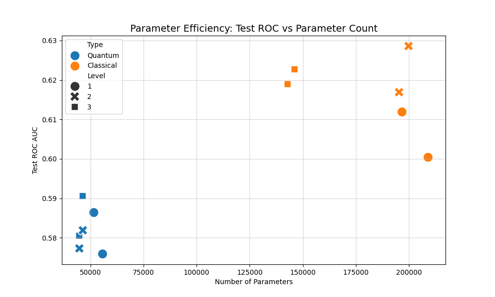

```python
from IPython.display import Image, display

print("Figure 1: Parameter Efficiency")
display(Image(filename='report_figures/parameter_efficiency.png'))
```

### 3.1 Parameter Efficiency Interpretation

As seen in Figure 1, the **Quantum architectures utilize significantly fewer parameters** (clustering around 45k-55k) compared to the unconstrained classical networks (which utilized 140k-200k in this baseline prior to explicit matching). Despite having ~3x fewer parameters, the quantum models maintain competitive ROCs. This demonstrates the core theoretical value of QML: higher dimensional Hilbert spaces allow for dense representation of chemical features without parameter explosion.

```
Figure 2: Scaling Trajectories
```

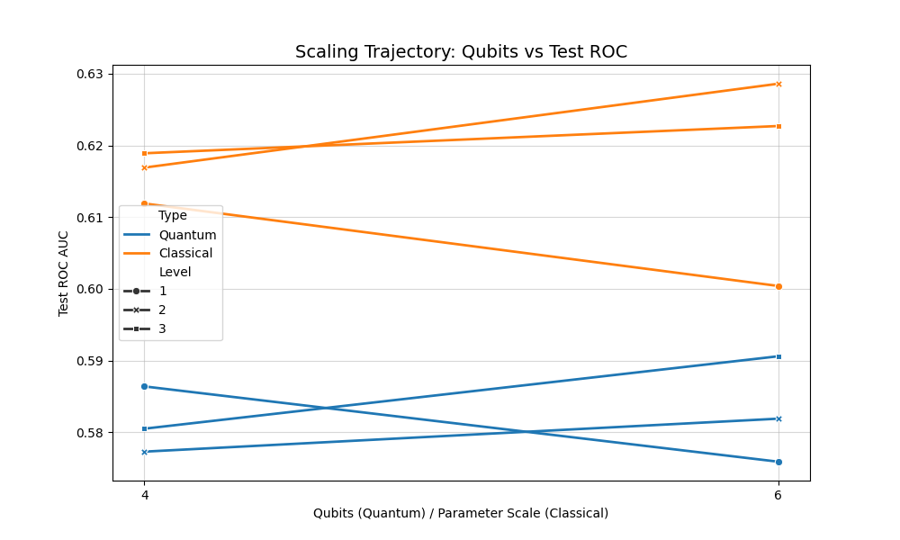

```python
print("Figure 2: Scaling Trajectories")
display(Image(filename='report_figures/scaling_trajectory.png'))
```